# Somateria mollissima escape distance in Kem’ region

V. Khaitov

## Сравнение индекса осторожности в Кеми и в Кандалаше

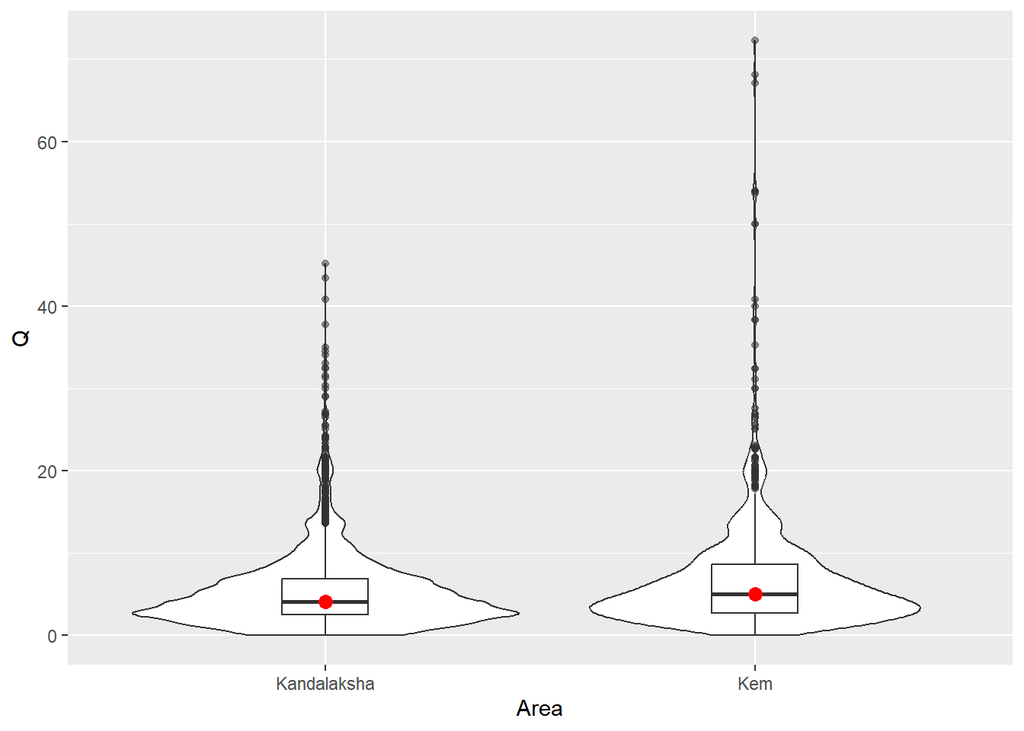

Видно, что в Кеми чуть более высокая медиана значения Q. Пи этом различия статстически значимые

Результаты теста Манна-Уитни для сравнения групп

| Параметр | Значение |
| --- | --- |
| W статистика | 2027516.5 |
| p-value | 0.00000000000008383 |
| Метод | Wilcoxon rank sum test with continuity correction |

Таким образом, в окрестностях Кеми, где нагрузка сбора пуха высокая, осторожность выше, чем в окрестностях Кандалакши.

## Сравннение осторожности при первичном и вторичном посещении гнезд в окрестностях Кеми

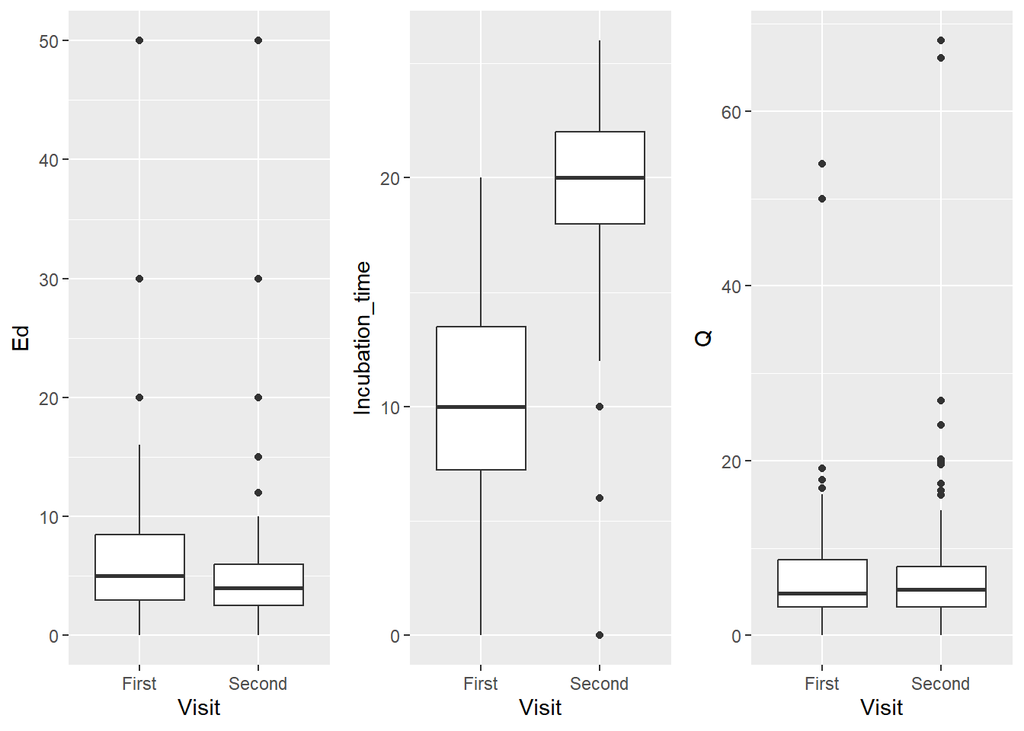

Результаты парного t-теста

| Параметр | Значение |
| --- | --- |
| t-статистика | -1.801 |
| df (степени свободы) | 139 |
| p-value | 0.07387 |
| Средняя разница | -1.353 |
| 95% ДИ нижняя граница | -2.839 |
| 95% ДИ верхняя граница | 0.132 |
| Метод | Paired t-test |

Если посмотреть по отдельным островам, то будет видно, что на островах Гага, Горелая Плоская, Горелая Северная, Тервонец Южный при повторном посещении Q становится чуть больше (довольно много точек выше линии Y=X).

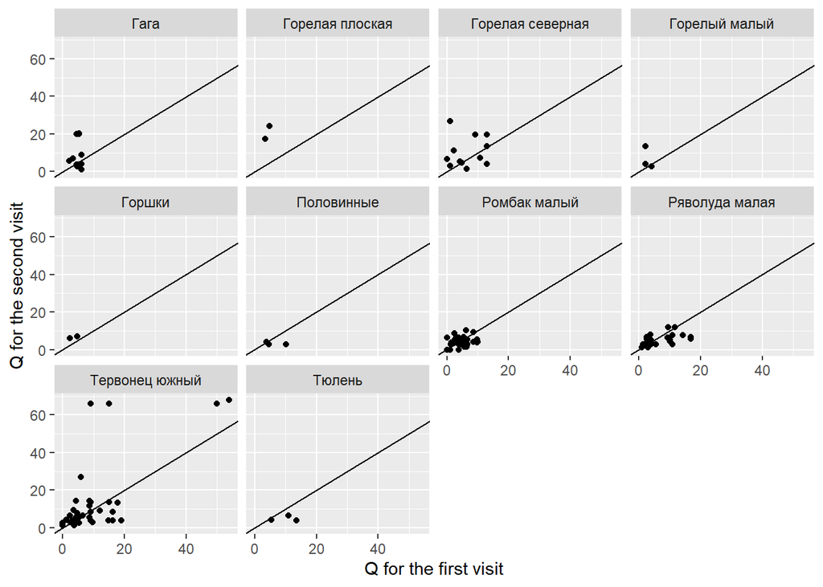

## Пространственное распределение Q

Вот так это выглядит если смотреть на все острова. В принципе, есть намек на то, что ближе к Кеми гаги более осторожные.

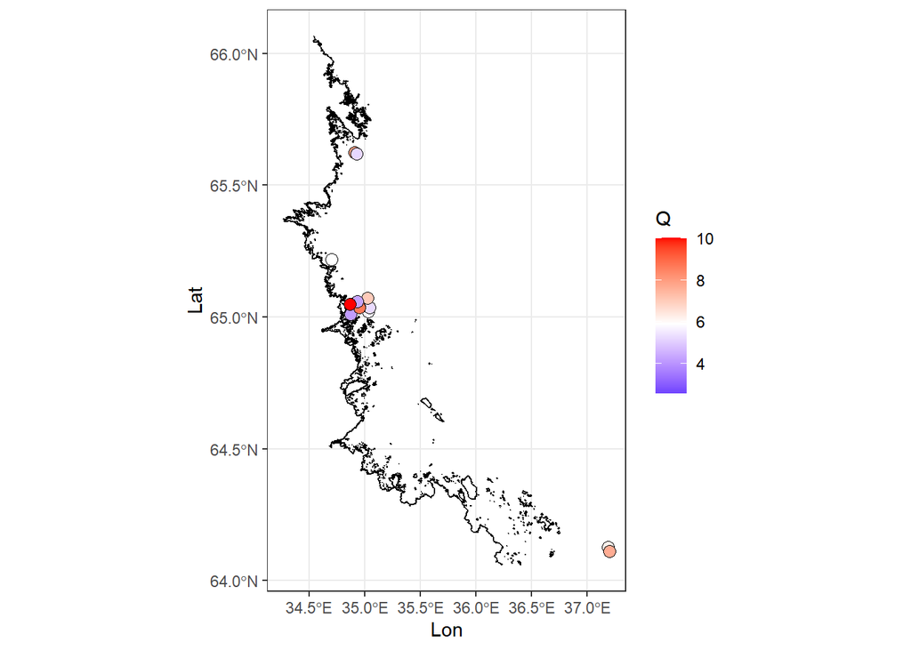

А это ближайшие к Кеми острова.

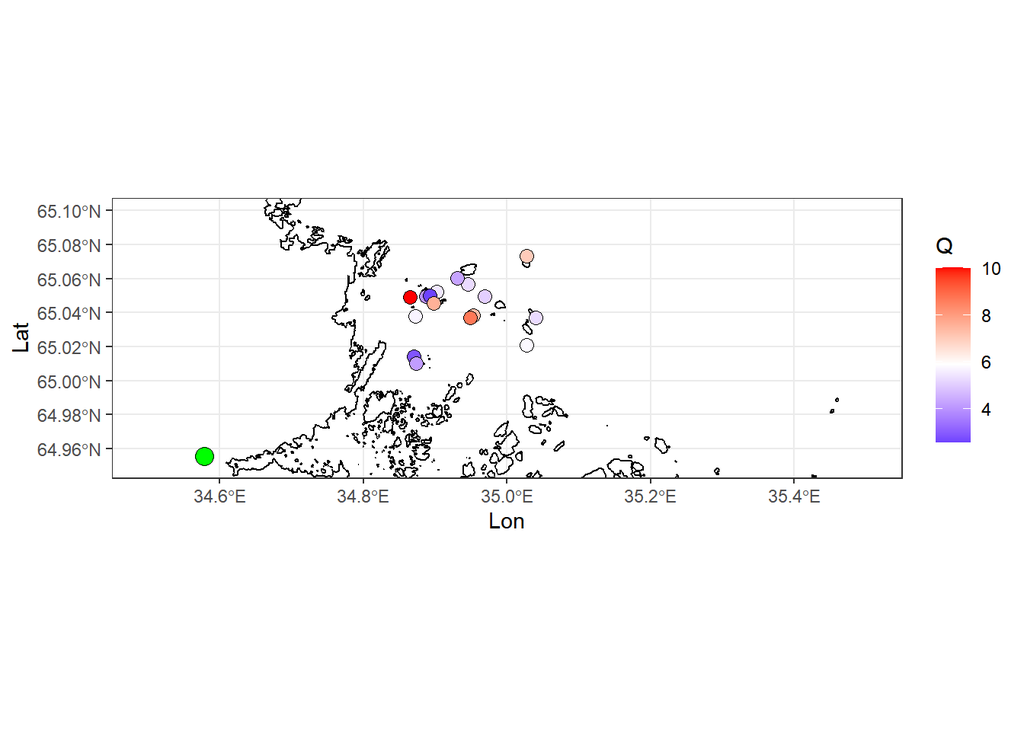

Пока я вижу пять-шесть островов, где гаги более осторжные и они не самые близкие к Кеми.

## Ответы на вопросы

**1. Зависимость дистанции слета от длительности инкубации.**

*Есть по данным АСК 80-х и 2000-х гг., нет по Кеми - сделать.*

По первичным данным получается вот такая картинка

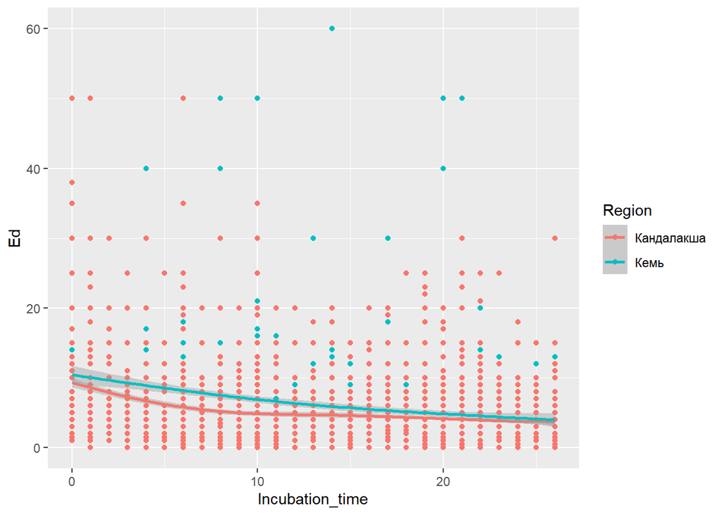

Зависимость в Кемском материале явно есть, но она совсем не такая как в Кандалакше! Даже модель можно не строить, видно, что форма зависимостей совершенно разная. При этом в Кандалакше гаги явно менее осторожные почти во все время насиживания.

Это, либо разные методики, либо реально в Кеми они более осторожные. Кроме того, явной логарифимческой зависимости, которая хоть как-то проглядывается в Кандалакше, в Кеми нет. Это еще один камень в сторону Q, куда АСК вставил логарифм, по-моему, чисто волюнтаристски. На фоне этого результата будет трудно обосновать, что логарифм был использован правильно.

Более того, если взять только данные по Кеми (Построил модель), то и здесь зависимсость будет довольно сильно варьировать. На выборках из региона “Юг” вообще нет связи с продолжительностью инкубации (см. summary от модели).

```
##
## Family: gaussian
## Link function: identity
##
## Formula:
## log(Ed + 1) ~ s(Incubation_time, by = Region, bs = "cs", k = 5) +
##     Region + s(Place, bs = "re")
##
## Parametric coefficients:
##             Estimate Std. Error t value Pr(>|t|)
## (Intercept)  1.65242    0.04782  34.558   <2e-16 ***
## RegionСевер -0.04271    0.11618  -0.368    0.713
## RegionЮг    -0.01742    0.12486  -0.139    0.889
## ---
## Signif. codes:  0 '***' 0.001 '**' 0.01 '*' 0.05 '.' 0.1 ' ' 1
##
## Approximate significance of smooth terms:
##                                    edf Ref.df      F p-value
## s(Incubation_time):RegionКемь   1.9635      4 34.019  <2e-16 ***
## s(Incubation_time):RegionСевер  1.5154      4  7.739  <2e-16 ***
## s(Incubation_time):RegionЮг     0.5122      4  0.259    0.16
## s(Place)                       11.9375     19  2.986  <2e-16 ***
## ---
## Signif. codes:  0 '***' 0.001 '**' 0.01 '*' 0.05 '.' 0.1 ' ' 1
##
## R-sq.(adj) =  0.131   Deviance explained = 14.2%
## fREML = 1399.6  Scale est. = 0.41394   n = 1408
```

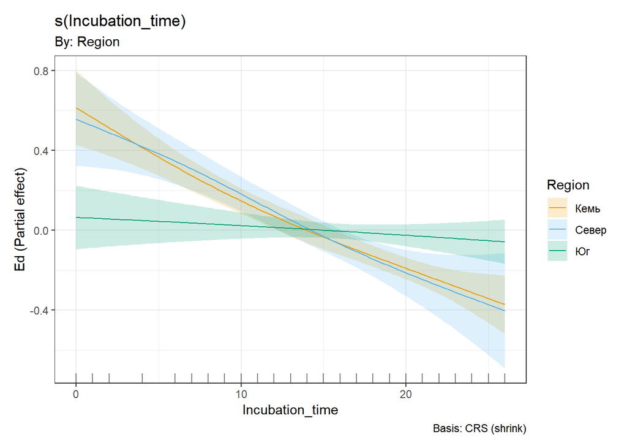

Не знаю, что там на “Юге”, но там гаги менее осторожные на первых этапах инкубации.

Далее, наблюдается и разная зависимость Ed от Incubation_Time и при разной степени открыторсти-закрытости гнезда.

```
##
## Family: gaussian
## Link function: identity
##
## Formula:
## log(Ed + 1) ~ s(Incubation_time, by = Cover, bs = "cs", k = 5) +
##     Cover + s(Place, bs = "re")
##
## Parametric coefficients:
##             Estimate Std. Error t value Pr(>|t|)
## (Intercept)  1.53732    0.04923  31.225  < 2e-16 ***
## Coverо       0.22822    0.05234   4.360  1.4e-05 ***
## Coverп       0.11707    0.04605   2.542   0.0111 *
## ---
## Signif. codes:  0 '***' 0.001 '**' 0.01 '*' 0.05 '.' 0.1 ' ' 1
##
## Approximate significance of smooth terms:
##                              edf Ref.df      F p-value
## s(Incubation_time):Coverз  1.122      4  3.551 0.00182 **
## s(Incubation_time):Coverо  1.475      4 15.425 < 2e-16 ***
## s(Incubation_time):Coverп  1.733      4 25.465 < 2e-16 ***
## s(Place)                  13.066     21  2.489 < 2e-16 ***
## ---
## Signif. codes:  0 '***' 0.001 '**' 0.01 '*' 0.05 '.' 0.1 ' ' 1
##
## R-sq.(adj) =   0.14   Deviance explained = 15.2%
## GCV = 0.41542  Scale est. = 0.4094    n = 1408
```

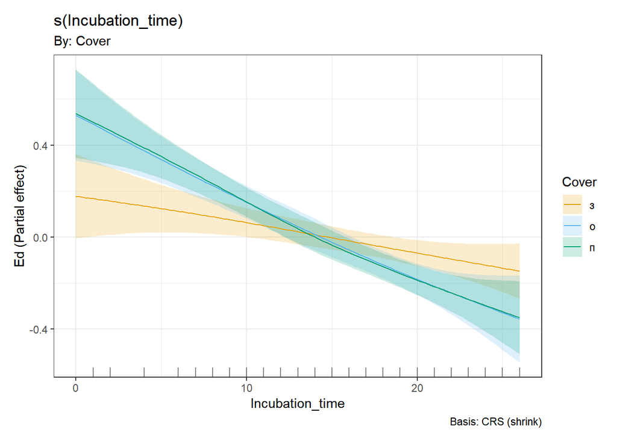

У гнезд, маркированных “з” (закрытые ?) осторожность на первых этапах инкубации ниже, чем у “о” (Открытые?) и “п” (это какие?). В этом, похоже, есть какая-то правда. НО! Это означает, что Q вообще не может быть универсальным показателем, который работает в разных регионах.

**2. Зависимость значения Q от частоты и опасности контактов с человеком (от района гнездования).**

*Есть по данным АСК 80-х и 2000-х гг., по Кеми сделано за 24 и 25 гг., добавить данные за 20 г.*

**3. Значение Q и Qd.**

*Есть по данным АСК 80-х, сделать по кемским данным.*

Итак, выловил блох каких смог. НО! Полной уверенности в том, что все правильно нет. Поэтому прверьте **внимательно**. Ниже таблица с перечнем тех гнезд, на которых изучена связь вероятности разорения с Q.

| Year | Nest_ID |
| --- | --- |
| 2024 | B1 |
| 2024 | B2 |
| 2024 | B3 |
| 2024 | B5 |
| 2024 | B6 |
| 2024 | B7 |
| 2024 | B8 |
| 2024 | B9 |
| 2024 | C1 |
| 2024 | C10 |
| 2024 | C11 |
| 2024 | C12 |
| 2024 | C14 |
| 2024 | C15 |
| 2024 | C16 |
| 2024 | C17 |
| 2024 | C18 |
| 2024 | C2 |
| 2024 | C20 |
| 2024 | C21 |
| 2024 | C22 |
| 2024 | C23 |
| 2024 | C24 |
| 2024 | C25 |
| 2024 | C26 |
| 2024 | C27 |
| 2024 | C28 |
| 2024 | C29 |
| 2024 | C3 |
| 2024 | C30 |

[output cut: 365 more lines]

```
##
## Call:
## glm(formula = Destroy ~ Q, family = "binomial", data = two_visits_destroy)
##
## Coefficients:
##             Estimate Std. Error z value Pr(>|z|)
## (Intercept) -1.94566    0.18624 -10.447   <2e-16 ***
## Q            0.02921    0.01358   2.151   0.0315 *
## ---
## Signif. codes:  0 '***' 0.001 '**' 0.01 '*' 0.05 '.' 0.1 ' ' 1
##
## (Dispersion parameter for binomial family taken to be 1)
##
##     Null deviance: 339.95  on 394  degrees of freedom
## Residual deviance: 335.71  on 393  degrees of freedom
##   (37 пропущенных наблюдений удалены)
## AIC: 339.71
##
## Number of Fisher Scoring iterations: 4
```

Удивительно, но зависимость статистически значимая. Эта зависимость описывается следующим уравнением:

$$P_{Destroy} = \frac{e^{-1.9 + 0.03Q}}{1+e^{-1.9 + 0.03Q}}$$

Вот график полученной модели

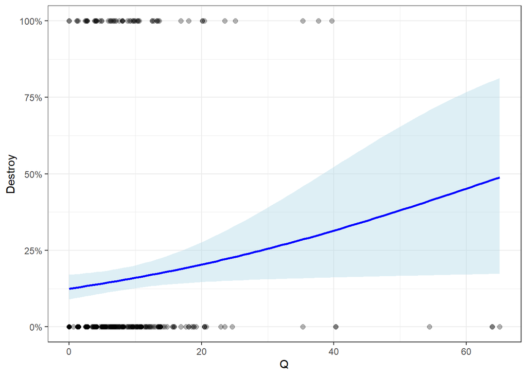

Форма зависимости, в целом, похожа на то, что у АСК. То есть у более осторожных самок смертность кладок выше. (По-моему, не логично, но у АСК так же).

Важное отличие от АСК - размах варьирования Q в Кеми сильно больше.

**4. Расчет вероятности гибели кладки (расчетные и эмпирические показатели).**

*Есть по данным АСК 80-х, сделать по кемским данным.*

Вот так выглядит связь вероятности гибели, Q и Времени инкубации, согласно полученной модели.

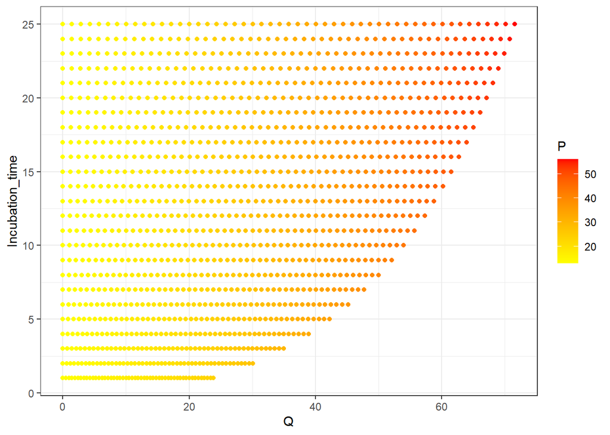

Честно говоря, рисунок, аналогичный приведенному у АСК (там где Qd) я не могу придумать как сделать.

Но форма связи этих трех величин похожая.

Что касается Qd, то 100% вероятности гибели эта модель не может предсказать в принципе (она логистическая, т.е. вероятность = 1 не может быть). Если взять веротяность равную 0.99 (99%), то тогда, после несложных вычислений, Qd = 217. Странное и нереалистичное число.

**5. Адаптация к антропогенному беспокойству.**

*Изменение осторожности по годам.*

*Есть по данным АСК 2005-11 гг., сделать по Кеми.*

По Кеми у меня пока всего три года. Вот что мы видим.

```
## Analysis of Variance Table
##
## Response: log(Q + 1)
##                Df Sum Sq Mean Sq F value  Pr(>F)
## factor(Year)    2   2.98  1.4891  3.1778 0.04198 *
## Residuals    1405 658.39  0.4686
## ---
## Signif. codes:  0 '***' 0.001 '**' 0.01 '*' 0.05 '.' 0.1 ' ' 1
```

Значимые межгодовые изменения в Кеми вроде как есть. НО! К этим результатам надо относиться с высокой степенью скепсиса. Прежде всего потому, что распределение Q очень асимметрично и приходится в качестве зависимой переменной использовать log(Q+1). То есть здесь уже двойное (!) логарифмирование Ed.

На картинке можно что-то увидеть: медианы, красные точки, в 2022 г. чуть выше общей за все годы медианы (горизонтальная линия), а в 2025 - чуть ниже. Но при таком размахе варьирования все различия сильно скрадываются.

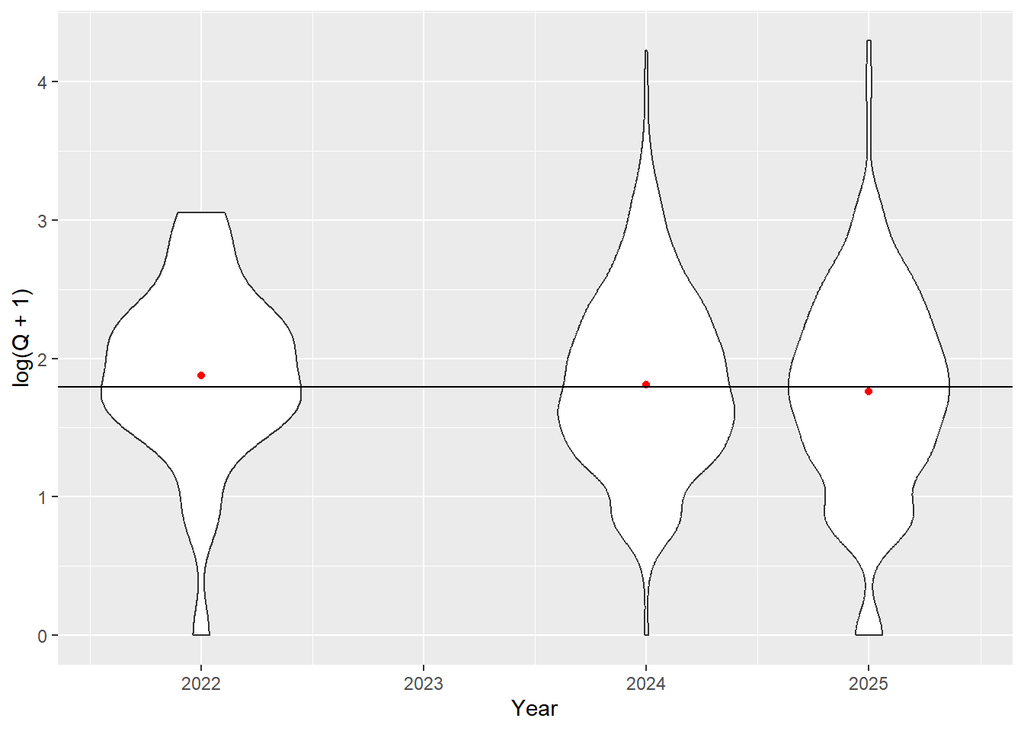

**6. Зависимость осторожности (Q) от количества яиц**

*Есть по данным АСК 2000-х, сделать по Кеми.*

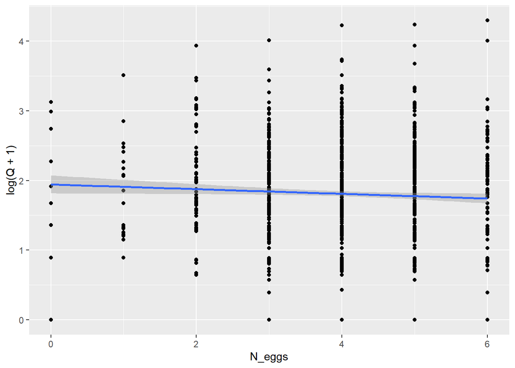

Да, уже на первичных данных видна отрицательная корреляция.

Вот более аккуратная оценка в статистической модели.

```
##
## Family: gaussian
## Link function: identity
##
## Formula:
## log(Q + 1) ~ s(N_eggs, bs = "cs", k = 5, by = Region) + Region +
##     s(Place, bs = "re")
##
## Parametric coefficients:
##             Estimate Std. Error t value Pr(>|t|)
## (Intercept)  1.73317    0.04523  38.316   <2e-16 ***
## RegionСевер  0.09100    0.09849   0.924    0.356
## RegionЮг     0.09142    0.11356   0.805    0.421
## ---
## Signif. codes:  0 '***' 0.001 '**' 0.01 '*' 0.05 '.' 0.1 ' ' 1
##
## Approximate significance of smooth terms:
##                             edf Ref.df     F p-value
## s(N_eggs):RegionКемь  2.941e+00      4 3.678 0.00179 **
## s(N_eggs):RegionСевер 3.849e-09      4 0.000 0.55313
## s(N_eggs):RegionЮг    1.636e+00      4 0.881 0.11429
## s(Place)              1.094e+01     19 2.492 < 2e-16 ***
## ---
## Signif. codes:  0 '***' 0.001 '**' 0.01 '*' 0.05 '.' 0.1 ' ' 1
##
## R-sq.(adj) =  0.0456   Deviance explained = 5.75%
## GCV = 0.45459  Scale est. = 0.44861   n = 1408
```

Опять же все по-разному на разных регионах. Значимая связь только в регионе “Кемь”. Да и там тоже связь какая-то не монотонная.

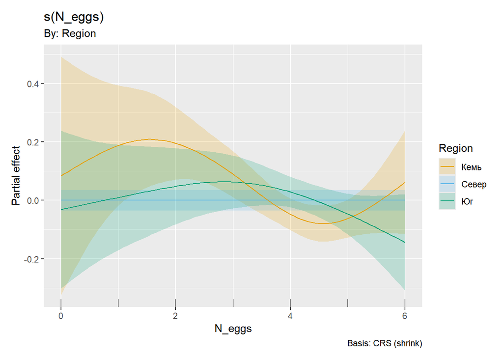

**7. Для Кеми сравнить Q на островах, где проводили и не проводили сбор пуха**

*Для островов в целом или для отдельных гнезд? (у каждого гнезда отмечено п(пух) - значит, его не собирали, или с(сено) - значит, пух собирали.*

Вот это выглядит так для гнезд при ПЕРВОМ осмотре.

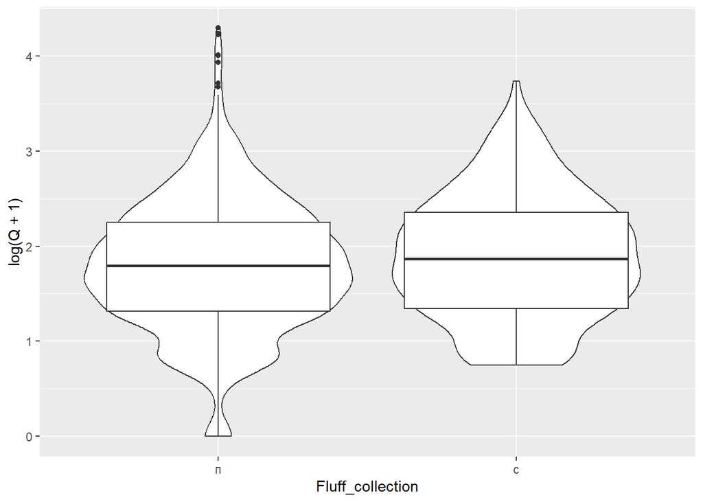

Сильных различий не вижу. Ну… Есть маленько более высокое значение Q для тех кто с сеном. Однако формальный тест на различия их, все-таки, выявляет.

```
##
##  Wilcoxon rank sum test with continuity correction
##
## data:  Q by Fluff_collection
## W = 120124, p-value = 0.02359
## alternative hypothesis: true location shift is not equal to 0
```

Так что есть статистически значимые различия. Там, где вместо пуха лежит сено, гаги более осторожные.

**8. Посмотреть индивидуальную вариативность:**

*каков разброс значений Q внутри одной популяции, насколько сильно различаются «смелые» и «осторожные» особи, по кандалакшским и кемским данным*

Вот переделанная картинка для сравнения Кандалакши и Кеми

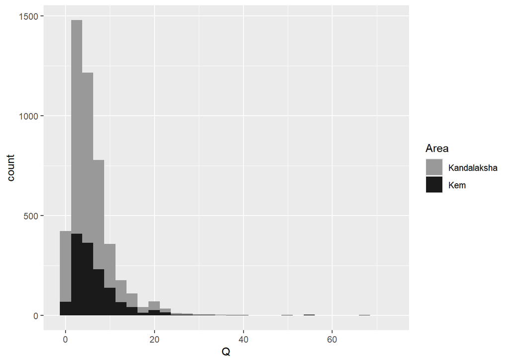

Вот еще один вариант этой картинки, но более информативный.

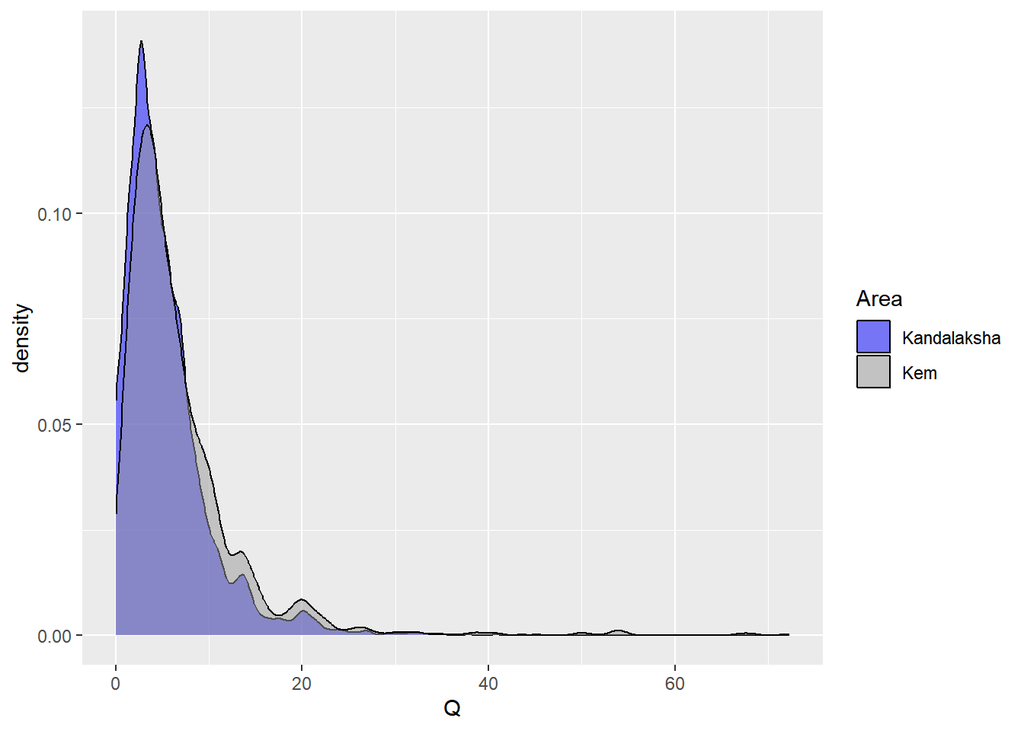

Здесь, кстати, хорошо видно, что оба распределения очень похожи: пики в одних и тех же местах. Однако правый хвост в распределниии в Кеми сильно длиннее. Последнее говорит о большей осторожности кемских гаг.

Если сжать правый хвост путем логарифмирования, то будет видно, что “подпики” менее осторожных гаг (левые пики) имеют более высокую частоту (density).

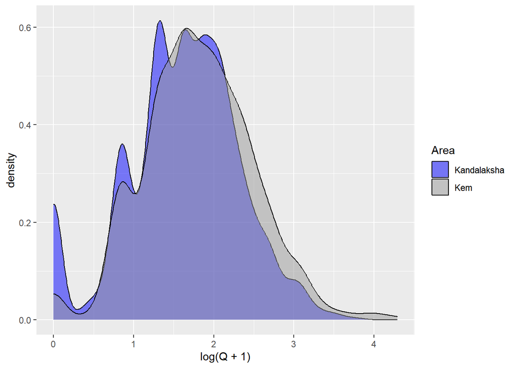